```r
binData <- function(df, column, max_bin){
# Function to pre-bin SVs by length
  binned_df = data.frame("bin"=seq(from=0,to=max_bin,by=10), count=0)
  for(i in 1:nrow(df)) {
    row <- df[i,]
    bin = floor(row[[column]]/10)*10
    binned_df[binned_df$bin==bin,]$count = binned_df[binned_df$bin==bin,]$count + 1
  }
  return(binned_df)
}

knitr::opts_chunk$set(echo = TRUE, warning = FALSE, message = FALSE)

library(ggplot2)
library(cowplot)
library(ggbeeswarm)
library(ggpubr)
#library(plyr)
library(dplyr)
library(kableExtra)
source("../lib/design.r")

htmltools::includeHTML("../html-chunks/nav.html")
```

[figure not shown]

```
Alignment and filtering steps:
1. BLAST mouse exons to all assembled contigs.
2. Exonerate mouse exons (as trimmed AA sequences) to matching contig for each sample.
3. Remove exons that have fewer than 175 samples with a matching BLAST hit.
4. Align exonerate hits with MAFFT.
5. Backtranslate to nucleotide sequences.
6. For each alignment, remove sequences that are >20% gaps.
7. For each alignment, remove 3-codon windows in which 2 or more codons have 2 or more gaps in >50% of sequences.
```

## Exons vs. BLAST hits

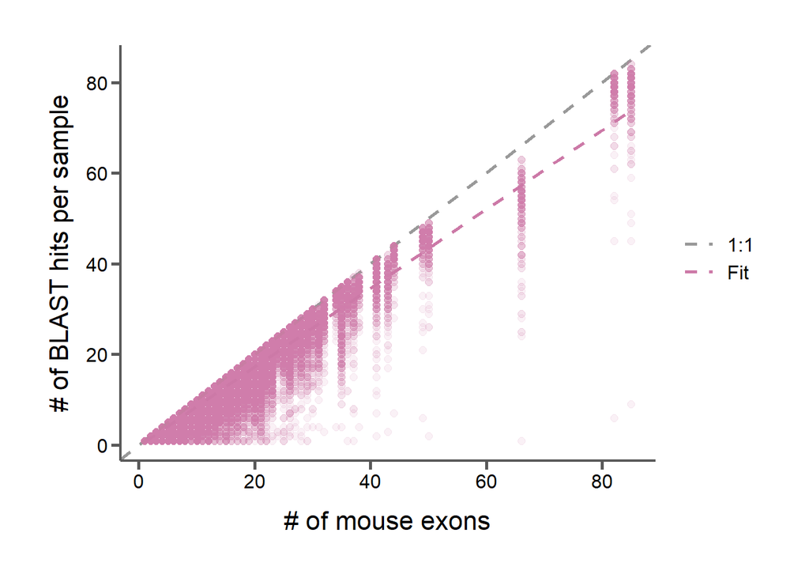

```r
blast_data = read.csv("../../data/aln-stats/sample-hits-exons.csv", header=T)

exons_v_bhits = ggplot(blast_data, aes(x=exons, y=blast.hits)) +
  geom_abline(aes(slope=1, intercept=0, color="1:1"), size=1, linetype="dashed", show.legend=F) +
  geom_point(size=2, alpha=0.1, color=corecol(pal="wilke", numcol=1, offset=6)) +
  geom_smooth(aes(color="Fit"), method="lm", linetype="dashed", se=F) +
  ylab("# of BLAST hits per sample") +
  xlab("# of mouse exons") +
  scale_color_manual(values=c("1:1"="#999999", "Fit"=corecol(pal="wilke", numcol=1, offset=6))) +
  bartheme() +
  theme(legend.position="right")
print(exons_v_bhits)
```

## BLAST hits vs. exonerate hits (no 175 hit threshold)

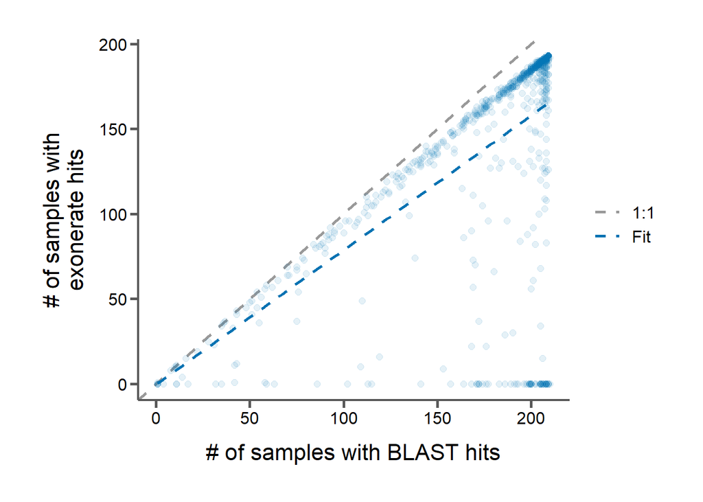

```r
targets_exonerate = read.csv("../../data/aln-stats/targets-exonerate.csv", header=T)

bhits_v_ehits = ggplot(targets_exonerate, aes(x=init.sample.hits, y=exonerate.sample.hits)) +
  geom_abline(aes(slope=1, intercept=0, color="1:1"), size=1, linetype="dashed", show.legend=F) +
  geom_point(size=2, alpha=0.1, color=corecol(pal="wilke", numcol=1, offset=4)) +
  geom_smooth(aes(color="Fit"), method="lm", linetype="dashed", se=F) +
  xlab("# of samples with BLAST hits") +
  ylab("# of samples with\nexonerate hits") +
  scale_color_manual(values=c("1:1"="#999999", "Fit"=corecol(pal="wilke", numcol=1, offset=4))) +
  bartheme() +
  theme(legend.position="right")
print(bhits_v_ehits)
```

# Mouse exons vs exonerate hits (no 175 hit threshold)

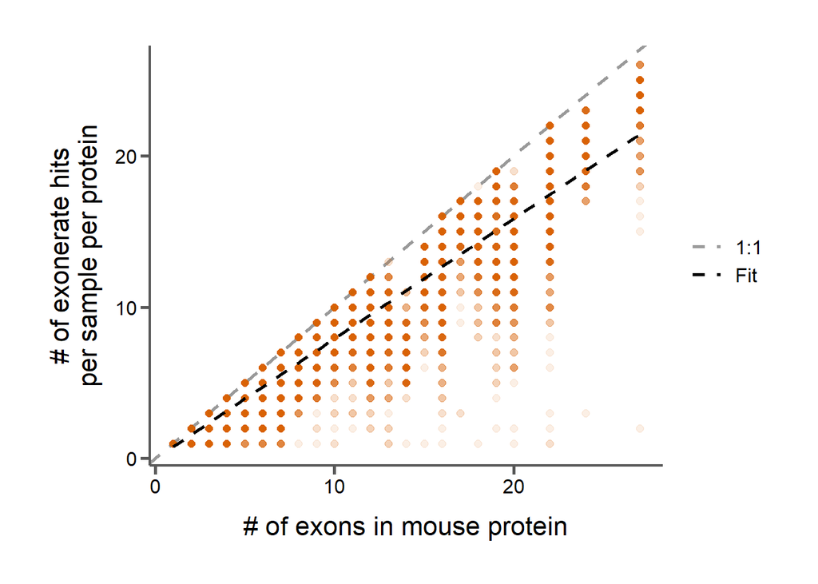

```r
sample_targets_exonerate = read.csv("../../data/aln-stats/sample-targets-exonerate.csv", header=T)

exons_v_hits = ggplot(sample_targets_exonerate, aes(x=mm.exons, y=exonerate.hits)) +
  geom_abline(aes(slope=1, intercept=0, color="1:1"), size=1, linetype="dashed", show.legend=F) +
  geom_point(size=2, alpha=0.1, color=corecol(pal="wilke", numcol=1, offset=5)) +
  geom_smooth(aes(color="Fit"), method="lm", linetype="dashed", se=F) +
  xlab("# of exons in mouse protein") +
  ylab("# of exonerate hits\nper sample per protein") +
  scale_color_manual(values=c("1:1"="#999999", "Fit"="#000000")) +
  bartheme() +
  theme(legend.position="right")
print(exons_v_hits)
```

# Alignment filtering

## Number of sequences per alignment

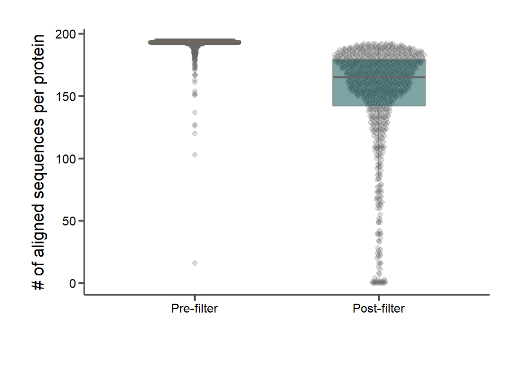

```r
aln_data = read.csv("../../data/aln-filters/aln-stats-f175-seq20-site50.tab", header=T, sep="\t", comment.char="#")
gbe_data = read.csv("../../data/aln-stats/roycroft-aln-stats.tab", header=T, sep="\t", comment.char="#")

filter_col = corecol(numcol=3)

pre_seqs = select(aln_data, align, pre.num.seqs)
pre_seqs$label = "Pre-filter"
names(pre_seqs)[2] = "num.seqs"

post_seqs = select(aln_data, align, post.num.seqs)
post_seqs$label = "Post-filter"
names(post_seqs)[2] = "num.seqs"

num_seqs = rbind(pre_seqs, post_seqs)

num_seqs$label = factor(num_seqs$label, levels=c("Pre-filter", "Post-filter"))

aln_seqs = ggplot(num_seqs, aes(x=label, y=num.seqs, fill=label)) +
  geom_quasirandom(size=2, width=0.25, alpha=0.25, color="#666666") +
  geom_boxplot(outlier.shape=NA, alpha=0.5, width=0.5, color="#666666") +
  ylab("# of aligned sequences per protein") +
  xlab("") +
  scale_fill_manual(labels=c("Pre-filter", "Post-filter"), values=filter_col) +
  scale_x_discrete(labels=c("Pre-filter", "Post-filter")) +
  #scale_y_continuous(expand=c(0,0)) +
  bartheme() +
  theme(legend.position="none")
print(aln_seqs)
```

## Length of alignment

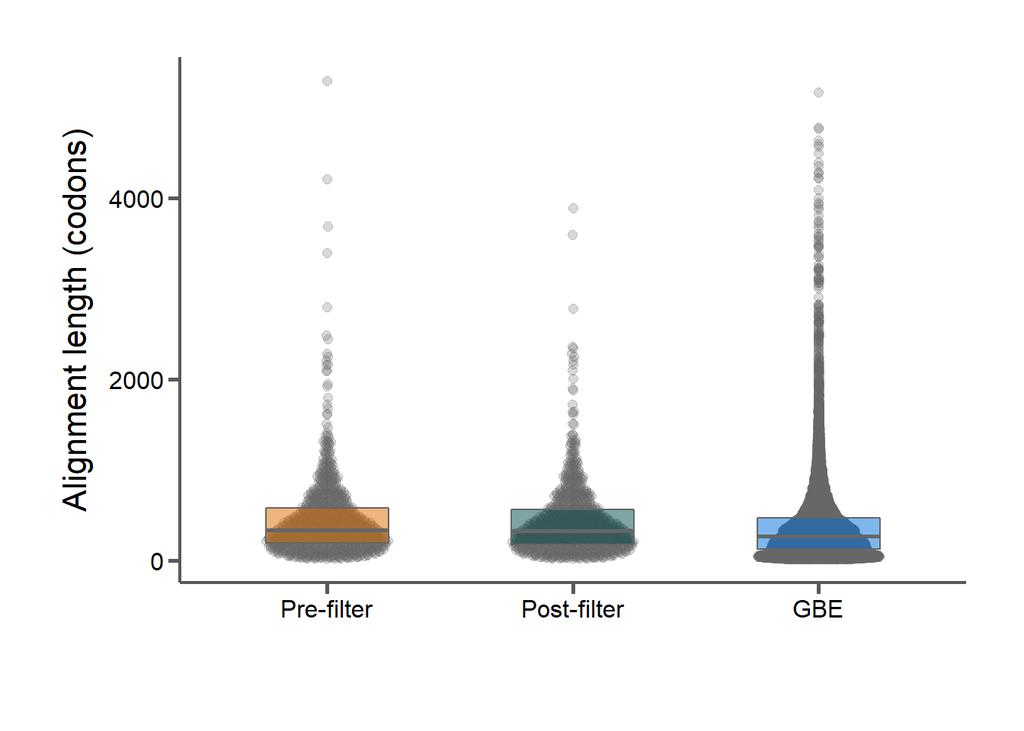

```r
pre_seqs = select(aln_data, align, pre.codon.aln.length)
pre_seqs$label = "Pre-filter"
names(pre_seqs)[2] = "aln.len"

post_seqs = select(aln_data, align, post.codon.aln.length)
post_seqs$label = "Post-filter"
names(post_seqs)[2] = "aln.len"

gbe_seqs = select(gbe_data, align, pre.codon.aln.length)
gbe_seqs$label = "GBE"
names(gbe_seqs)[2] = "aln.len"
gbe_seqs = subset(gbe_seqs, aln.len < 10000)


num_seqs = rbind(pre_seqs, post_seqs, gbe_seqs)

num_seqs$label = factor(num_seqs$label, levels=c("Pre-filter", "Post-filter", "GBE"))

aln_len = ggplot(num_seqs, aes(x=label, y=aln.len, fill=label)) +
  geom_quasirandom(size=2, width=0.25, alpha=0.25, color="#666666") +
  geom_boxplot(outlier.shape=NA, alpha=0.5, width=0.5, color="#666666") +
  ylab("Alignment length (codons)") +
  xlab("") +
  scale_fill_manual(labels=c("Pre-filter", "Post-filter", "GBE"), values=filter_col) +
  scale_x_discrete(labels=c("Pre-filter", "Post-filter", "GBE")) +
  #scale_y_continuous(expand=c(0,0)) +
  bartheme() +
  theme(legend.position="none")
print(aln_len)
```

```r
# bin_width = 100
#
# bins = seq(0,6000,by=bin_width)
# bin_labels = seq(1,6000,by=bin_width)
# pre_counts = hist(aln_data$pre.codon.aln.length, breaks=bins, include.lowest=T, plot=F)$counts
# pre_binned = data.frame("bin"=bin_labels, "count"=pre_counts, filter="Pre-filter")
#
# filter_counts = hist(aln_data$post.codon.aln.length, breaks=bins, include.lowest=T, plot=F)$counts
# filter_binned = data.frame("bin"=bin_labels, "count"=filter_counts, filter="Post-filter")
#
# binned_data = rbind.fill(pre_binned, filter_binned)
# col = corecol(numcol=2)
# lab = c("Pre-filter", "Post-filter")
# #ylabels = c("1200", as.character(seq(from=0, to=7000, by=1000)))
# ylabels = as.character(seq(from=-200, to=200, by=100))
#
# dualp = ggplot(binned_data, aes(x = bin, y = ifelse(filter == "Post-filter",-1, 1)*count, fill = filter)) +
#   geom_col(width=bin_width) +
#   geom_hline(yintercept=0) +
#   scale_x_continuous(name = "dS", limits = c(-bin_width, 7000), expand = c(0, 0)) +
#   scale_y_continuous(name = "# Transcripts", limits=c(-200,200), breaks = 100*(-2:2), labels=ylabels) +
#   scale_fill_manual(name="", limits=lab, values=col) +
#   bartheme()
# print(dualp)
```

## Avg. non-gapped sequence length per protein

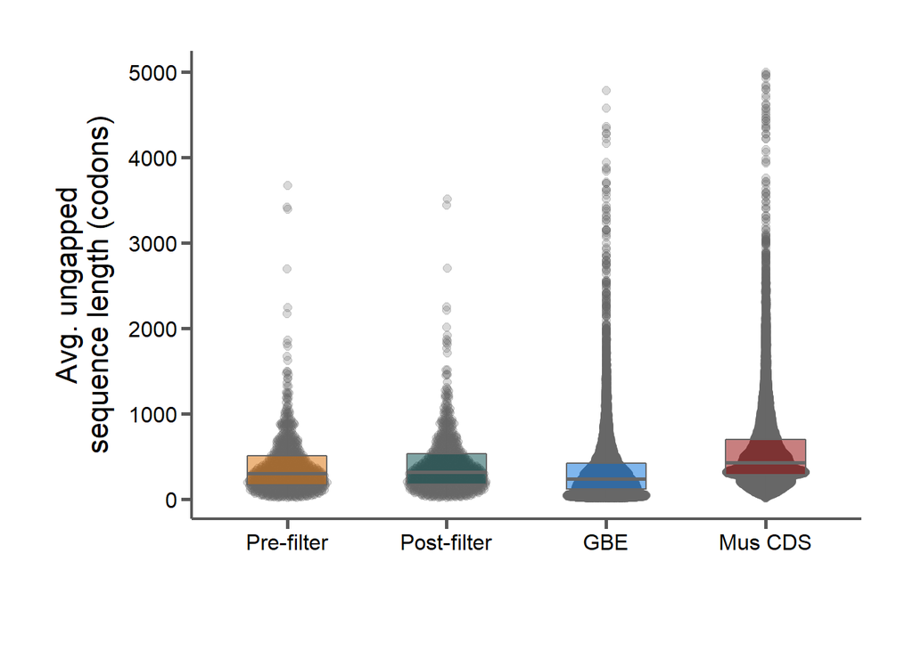

```r
mus_data = read.csv("../../data/Mus_best-transcript_all-counts_metadata.csv", header=TRUE)
mus_data = subset(mus_data, feature_type=="CDS")
mus_lens = select(mus_data, transcript_id, target_length)
mus_lens = mus_lens %>% group_by(transcript_id) %>% summarize(nongap.len=sum(target_length))
mus_lens$nongap.len = mus_lens$nongap.len / 3
mus_lens$label = "Mus CDS"
names(mus_lens)[1] = "align"
mus_lens = subset(mus_lens, nongap.len < 5000)

pre_seqs = select(aln_data, align, pre.avg.nongap.length)
pre_seqs$label = "Pre-filter"
names(pre_seqs)[2] = "nongap.len"

post_seqs = select(aln_data, align, post.avg.nongap.length)
post_seqs$label = "Post-filter"
names(post_seqs)[2] = "nongap.len"

gbe_seqs = select(gbe_data, align, pre.avg.nongap.length)
gbe_seqs$label = "GBE"
names(gbe_seqs)[2] = "nongap.len"
gbe_seqs = subset(gbe_seqs, nongap.len < 10000)


num_seqs = rbind(pre_seqs, post_seqs, gbe_seqs, mus_lens)

num_seqs$label = factor(num_seqs$label, levels=c("Pre-filter", "Post-filter", "GBE", "Mus CDS"))

nongap_len = ggplot(num_seqs, aes(x=label, y=nongap.len, fill=label)) +
  geom_quasirandom(size=2, width=0.25, alpha=0.25, color="#666666") +
  geom_boxplot(outlier.shape=NA, alpha=0.5, width=0.5, color="#666666") +
  ylab("Avg. ungapped\nsequence length (codons)") +
  xlab("") +
  scale_fill_manual(labels=c("Pre-filter", "Post-filter", "GBE", "Mus CDS"), values=corecol()) +
  scale_x_discrete(labels=c("Pre-filter", "Post-filter", "GBE", "Mus CDS")) +
  #scale_y_continuous(expand=c(0,0)) +
  bartheme() +
  theme(legend.position="none")
print(nongap_len)
```

## Number of sequences per alignment that are >20% gap (pre-filter)

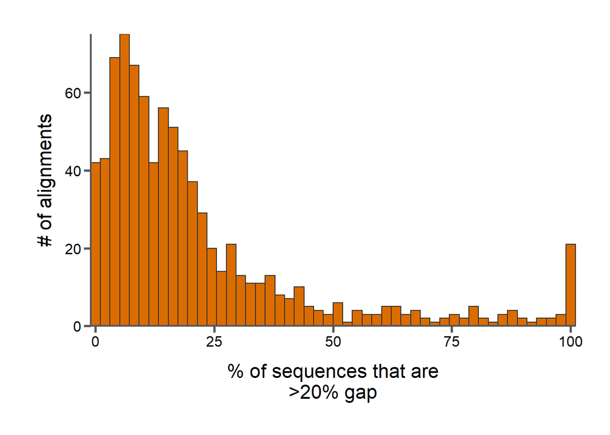

```r
aln_data$pre.gappy.seqs = (aln_data$pre.gappy.seqs / aln_data$pre.num.seqs) * 100
aln_20_gaps_seqs = ggplot(aln_data, aes(x=pre.gappy.seqs)) +
  geom_histogram(fill=filter_col[1], color="#333333", bins=50) +
  scale_x_continuous(expand=c(0,0)) +
  scale_y_continuous(expand=c(0,0)) +
  xlab("% of sequences that are\n>20% gap") +
  ylab("# of alignments") +
  bartheme()
print(aln_20_gaps_seqs)
```

## Number of sites that are >20% gap (pre-filter)

[figure not shown]

```r
pre_sites = select(aln_data, align, pre.gappy.sites)
pre_sites$label = "Pre-filter"
names(pre_sites)[2] = "perc.sites"

post_sites = select(aln_data, align, post.gappy.sites)
post_sites$label = "Post-filter"
names(post_sites)[2] = "perc.sites"

num_sites = rbind(pre_sites, post_sites)

num_sites$label = factor(num_sites$label, levels=c("Pre-filter", "Post-filter"))

aln_20_gap_sites = ggplot(num_sites, aes(x=label, y=perc.sites, fill=label)) +
  geom_quasirandom(size=2, width=0.25, alpha=0.25, color="#666666") +
  geom_boxplot(outlier.shape=NA, alpha=0.75, width=0.5, color="#666666") +
  ylab("# of sites ") +
  xlab("") +
  scale_fill_manual(labels=c("Pre-filter", "Post-filter"), values=filter_col) +
  scale_x_discrete(labels=c("Pre-filter", "Post-filter")) +
  #scale_y_continuous(expand=c(0,0)) +
  bartheme() +
  theme(legend.position="none")
print(aln_20_gap_sites)
```

```r
# aln_20_gap_sites = ggplot(aln_data, aes(x=1, y=pre.percent.sites.20.gap)) +
#   geom_quasirandom(size=2, width=0.25) +
#   geom_boxplot(outlier.shape=NA, alpha=0.3, width=0.5, fill="transparent", color="#666666") +
#   geom_quasirandom(data=aln_data, aes(x=2, y=post.percent.sites.20.gap), size=2, width=0.25) +
#   geom_boxplot(data=aln_data, aes(x=2, y=post.percent.sites.20.gap), outlier.shape=NA, alpha=0.3, width=0.5, fill="transparent", color="#666666") +
#   #scale_y_continuous(expand=c(0,0)) +
#   bartheme()
# print(aln_20_gap_sites)
```

# Alignment filter data

A look at the effects of varying all three filters:

1. Filtering the required number of samples present for exonerate. Targets with fewer than [0, 50, 100, 150, 175, 200] sample hits will be filtered. This is the presence filter denoted “P”.
2. Filtering sequences that are more than [20, 40, 60, 80, 100]% gaps. This is the sequence filter denoted as “S”.
3. Filtering codon sites that, among sliding windows of 3 codons, have at least 2 gaps in at least 2 codons in [25, 50, 75, 100]% of samples. This is the codon site filter denoted as “C”.

```r
p0s20c50 = read.csv("../../data/aln-filters/aln-stats-f0-seq20-site50.tab", header=T, comment.char="#", sep="\t")
p0s20c50$label = "P0S20C50"

p0s40c50 = read.csv("../../data/aln-filters/aln-stats-f0-seq40-site50.tab", header=T, comment.char="#", sep="\t")
p0s40c50$label = "P0S40C50"

p0s60c50 = read.csv("../../data/aln-filters/aln-stats-f0-seq60-site50.tab", header=T, comment.char="#", sep="\t")
p0s60c50$label = "P0S60C50"

p0s80c50 = read.csv("../../data/aln-filters/aln-stats-f0-seq80-site50.tab", header=T, comment.char="#", sep="\t")
p0s80c50$label = "P0S80C50"

p0s100c50 = read.csv("../../data/aln-filters/aln-stats-f0-seq100-site50.tab", header=T, comment.char="#", sep="\t")
p0s100c50$label = "P0S100C50"


p0s20c25 = read.csv("../../data/aln-filters/aln-stats-f0-seq20-site25.tab", header=T, comment.char="#", sep="\t")
p0s20c25$label = "P0S20C25"

p0s20c75 = read.csv("../../data/aln-filters/aln-stats-f0-seq20-site75.tab", header=T, comment.char="#", sep="\t")
p0s20c75$label = "P0S20C75"

p0s20c100 = read.csv("../../data/aln-filters/aln-stats-f0-seq20-site100.tab", header=T, comment.char="#", sep="\t")
p0s20c100$label = "P0S20C100"


p50s20c50 = read.csv("../../data/aln-filters/aln-stats-f50-seq20-site50.tab", header=T, comment.char="#", sep="\t")
p50s20c50$label = "P50S20C50"

p100s20c50 = read.csv("../../data/aln-filters/aln-stats-f100-seq20-site50.tab", header=T, comment.char="#", sep="\t")
p100s20c50$label = "P100S20C50"

p150s20c50 = read.csv("../../data/aln-filters/aln-stats-f150-seq20-site50.tab", header=T, comment.char="#", sep="\t")
p150s20c50$label = "P150S20C50"


p175s20c50 = read.csv("../../data/aln-filters/aln-stats-f175-seq20-site50.tab", header=T, comment.char="#", sep="\t")
p175s20c50$label = "P175S20C50"

p175s40c50 = read.csv("../../data/aln-filters/aln-stats-f175-seq20-site50.tab", header=T, comment.char="#", sep="\t")
p175s40c50$label = "P175S40C50"

p175s60c50 = read.csv("../../data/aln-filters/aln-stats-f175-seq20-site50.tab", header=T, comment.char="#", sep="\t")
p175s60c50$label = "P175S60C50"

p175s80c50 = read.csv("../../data/aln-filters/aln-stats-f175-seq20-site50.tab", header=T, comment.char="#", sep="\t")
p175s80c50$label = "P175S80C50"

p175s100c50 = read.csv("../../data/aln-filters/aln-stats-f175-seq20-site50.tab", header=T, comment.char="#", sep="\t")
p175s100c50$label = "P175S100C50"


p175s20c25 = read.csv("../../data/aln-filters/aln-stats-f175-seq20-site25.tab", header=T, comment.char="#", sep="\t")
p175s20c25$label = "P175S20C25"

p175s20c75 = read.csv("../../data/aln-filters/aln-stats-f175-seq20-site75.tab", header=T, comment.char="#", sep="\t")
p175s20c75$label = "P175S20C75"

p175s20c100 = read.csv("../../data/aln-filters/aln-stats-f175-seq20-site100.tab", header=T, comment.char="#", sep="\t")
p175s20c100$label = "P175S20C100"


p200s20c50 = read.csv("../../data/aln-filters/aln-stats-f200-seq20-site50.tab", header=T, comment.char="#", sep="\t")
p200s20c50$label = "P200S20C50"
```

## Varying the Presence (P) filter

Filtering targets with exonerate matches in less than [0, 50, 100, 150, 175, 200] samples

Alignment length (codons)

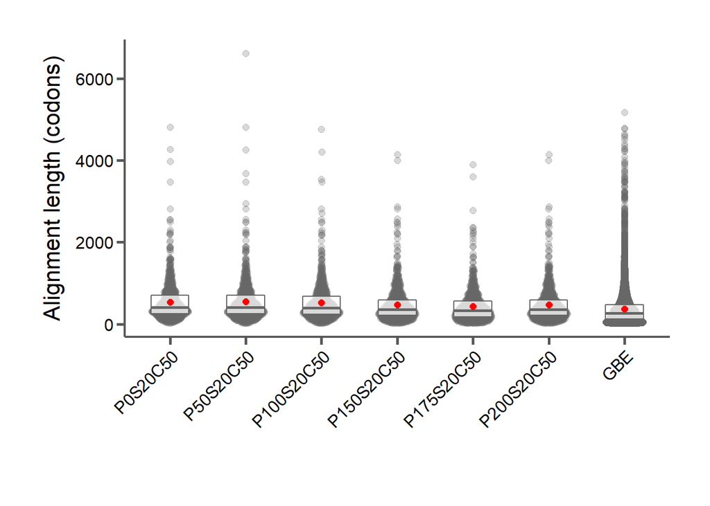

```r
#gbe_seqs = select(gbe_data, align, pre.codon.aln.length)
gbe_data$label = "GBE"
names(gbe_data)[3] = "post.codon.aln.length"
gbe_lens = select(gbe_data, align, label, post.codon.aln.length)
gbe_lens = subset(gbe_lens, post.codon.aln.length < 10000)


p_data = rbind(p0s20c50, p50s20c50, p100s20c50, p150s20c50, p175s20c50, p200s20c50)
p_data = select(p_data, align, label, post.codon.aln.length)

p_data = rbind(p_data, gbe_lens)

p_means = select(p_data, label, post.codon.aln.length)
p_means = p_means %>% group_by(label) %>% summarize(post.codon.aln.length=mean(post.codon.aln.length, na.rm=T))

p_data$label = factor(p_data$label, levels=c("P0S20C50", "P50S20C50", "P100S20C50", "P150S20C50", "P175S20C50", "P200S20C50", "GBE"), ordered=T)
#levels(p_data$label) = c("P0S20C50", "P50S20C50", "P100S20C50", "P150S20C50", "P175S20C50", "P200S20C50", "GBE"), ordered=T)


p_means$label = factor(p_means$label, levels=c("P0S20C50", "P50S20C50", "P100S20C50", "P150S20C50", "P175S20C50", "P200S20C50", "GBE"), ordered=T)
#p_means$label = as.factor(p_means$label)
#levels(p_means$label) = c("P0S20C50", "P50S20C50", "P100S20C50", "P150S20C50", "P175S20C50", "P200S20C50")

p_lens = ggplot(p_data, aes(x=label, y=post.codon.aln.length, group=label)) +
  geom_quasirandom(size=2, width=0.25, alpha=0.25, color="#666666") +
  geom_boxplot(outlier.shape=NA, alpha=0.75, width=0.5, color="#666666") +
  geom_point(data=p_means, aes(x=label, y=post.codon.aln.length), size=2, color="red") +
  geom_line(data=p_means, aes(x=label, y=post.codon.aln.length), size=2, color="blue") +
  ylab("Alignment length (codons)") +
  xlab("") +
  #scale_fill_manual(labels=c("Pre-filter", "Post-filter"), values=filter_col) +
  #scale_x_discrete(labels=c("Pre-filter", "Post-filter")) +
  #scale_y_continuous(expand=c(0,0)) +
  bartheme() +
  theme(legend.position="none", axis.text.x = element_text(angle=45, hjust=1))
print(p_lens)
```

```r
p_means %>% kable() %>% kable_styling(bootstrap_options=c("striped", "condended", "responsive"), full_width=F)
```

| label | post.codon.aln.length |
| --- | --- |
| GBE | 372.6928 |
| P0S20C50 | 541.0621 |
| P100S20C50 | 520.8391 |
| P150S20C50 | 474.8875 |
| P175S20C50 | 433.4337 |
| P200S20C50 | 474.8875 |
| P50S20C50 | 547.4366 |

Ungapped alignment length (codons)

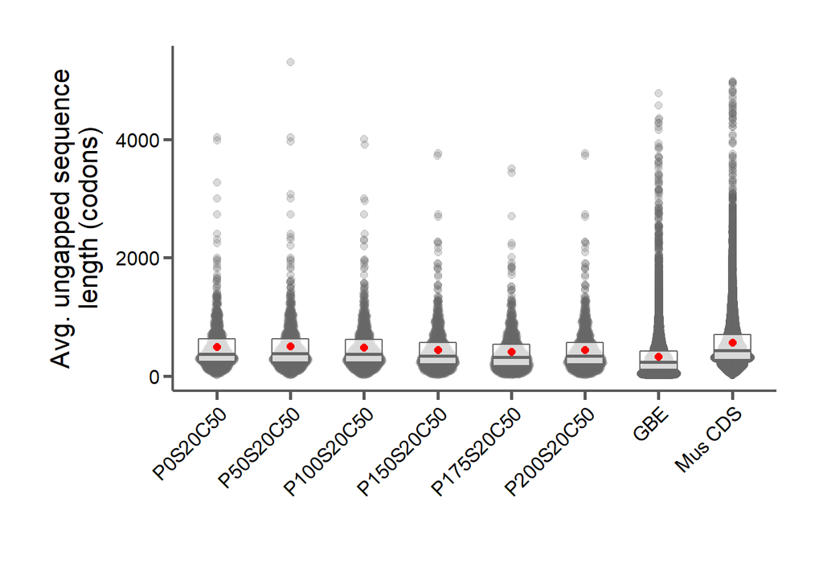

```r
#gbe_seqs = select(gbe_data, align, pre.codon.aln.length)
gbe_data$label = "GBE"
names(gbe_data)[4] = "post.avg.nongap.length"
gbe_lens = select(gbe_data, align, label, post.avg.nongap.length)
gbe_lens = subset(gbe_lens, post.avg.nongap.length < 10000)

mus_lens = select(mus_data, transcript_id, target_length)
mus_lens = mus_lens %>% group_by(transcript_id) %>% summarize(post.avg.nongap.length=sum(target_length))
mus_lens$post.avg.nongap.length = mus_lens$post.avg.nongap.length / 3
mus_lens$label = "Mus CDS"
names(mus_lens)[1] = "align"
mus_lens = subset(mus_lens, post.avg.nongap.length < 5000)


p_data = rbind(p0s20c50, p50s20c50, p100s20c50, p150s20c50, p175s20c50, p200s20c50)
p_data = select(p_data, align, label, post.avg.nongap.length)

p_data = rbind(p_data, gbe_lens, mus_lens)

p_means = select(p_data, label, post.avg.nongap.length)
p_means = p_means %>% group_by(label) %>% summarize(post.avg.nongap.length=mean(post.avg.nongap.length, na.rm=T))

p_data$label = factor(p_data$label, levels=c("P0S20C50", "P50S20C50", "P100S20C50", "P150S20C50", "P175S20C50", "P200S20C50", "GBE", "Mus CDS"), ordered=T)
#levels(p_data$label) = c("P0S20C50", "P50S20C50", "P100S20C50", "P150S20C50", "P175S20C50", "P200S20C50", "GBE"), ordered=T)


p_means$label = factor(p_means$label, levels=c("P0S20C50", "P50S20C50", "P100S20C50", "P150S20C50", "P175S20C50", "P200S20C50", "GBE", "Mus CDS"), ordered=T)
#p_means$label = as.factor(p_means$label)
#levels(p_means$label) = c("P0S20C50", "P50S20C50", "P100S20C50", "P150S20C50", "P175S20C50", "P200S20C50")

p_lens = ggplot(p_data, aes(x=label, y=post.avg.nongap.length, group=label)) +
  geom_quasirandom(size=2, width=0.25, alpha=0.25, color="#666666") +
  geom_boxplot(outlier.shape=NA, alpha=0.75, width=0.5, color="#666666") +
  geom_point(data=p_means, aes(x=label, y=post.avg.nongap.length), size=2, color="red") +
  geom_line(data=p_means, aes(x=label, y=post.avg.nongap.length), size=2, color="blue") +
  ylab("Avg. ungapped sequence\nlength (codons)") +
  xlab("") +
  #scale_fill_manual(labels=c("Pre-filter", "Post-filter"), values=filter_col) +
  #scale_x_discrete(labels=c("Pre-filter", "Post-filter")) +
  #scale_y_continuous(expand=c(0,0)) +
  bartheme() +
  theme(legend.position="none", axis.text.x = element_text(angle=45, hjust=1))
print(p_lens)
```

```r
p_means %>% kable() %>% kable_styling(bootstrap_options=c("striped", "condended", "responsive"), full_width=F)
```

| label | post.avg.nongap.length |
| --- | --- |
| GBE | 332.1052 |
| Mus CDS | 569.7054 |
| P0S20C50 | 493.6076 |
| P100S20C50 | 481.4933 |
| P150S20C50 | 445.9642 |
| P175S20C50 | 409.8810 |
| P200S20C50 | 445.9642 |
| P50S20C50 | 500.1466 |

## Varying the gappy sequence (S) filter

Alignment length (codons)

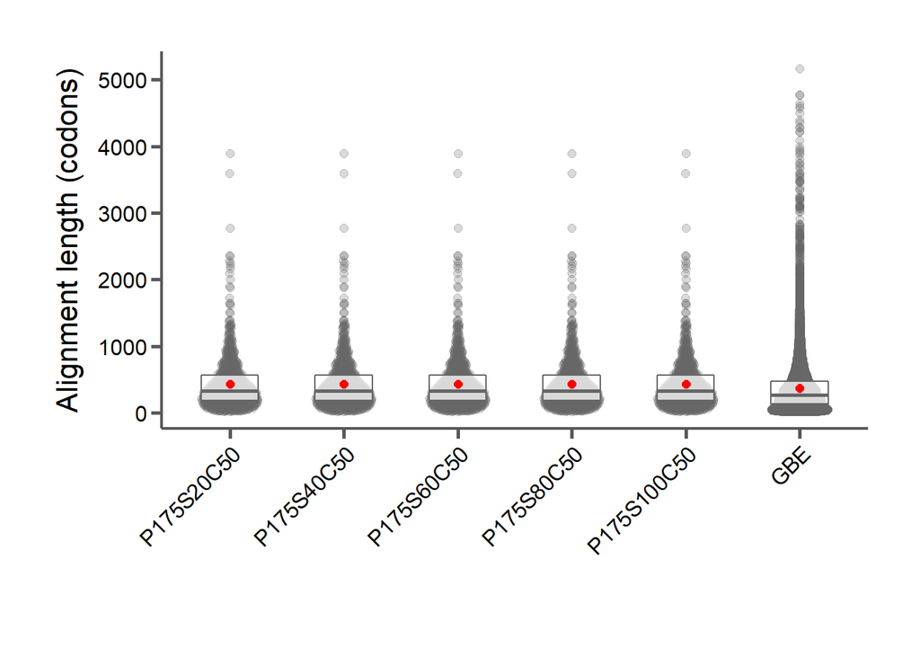

```r
#gbe_seqs = select(gbe_data, align, pre.codon.aln.length)
gbe_data$label = "GBE"
names(gbe_data)[3] = "post.codon.aln.length"
gbe_lens = select(gbe_data, align, label, post.codon.aln.length)
gbe_lens = subset(gbe_lens, post.codon.aln.length < 10000)


p_data = rbind(p175s20c50, p175s40c50, p175s60c50, p175s80c50, p175s100c50)
p_data = select(p_data, align, label, post.codon.aln.length)

p_data = rbind(p_data, gbe_lens)

p_means = select(p_data, label, post.codon.aln.length)
p_means = p_means %>% group_by(label) %>% summarize(post.codon.aln.length=mean(post.codon.aln.length, na.rm=T))

p_data$label = factor(p_data$label, levels=c("P175S20C50", "P175S40C50", "P175S60C50", "P175S80C50", "P175S100C50", "GBE"), ordered=T)
#levels(p_data$label) = c("P0S20C50", "P50S20C50", "P100S20C50", "P150S20C50", "P0S20C50", "P200S20C50", "GBE"), ordered=T)


p_means$label = factor(p_means$label, levels=c("P175S20C50", "P175S40C50", "P175S60C50", "P175S80C50", "P175S100C50", "GBE"), ordered=T)
#p_means$label = as.factor(p_means$label)
#levels(p_means$label) = c("P0S20C50", "P50S20C50", "P100S20C50", "P150S20C50", "P0S20C50", "P200S20C50")

p_lens = ggplot(p_data, aes(x=label, y=post.codon.aln.length, group=label)) +
  geom_quasirandom(size=2, width=0.25, alpha=0.25, color="#666666") +
  geom_boxplot(outlier.shape=NA, alpha=0.75, width=0.5, color="#666666") +
  geom_point(data=p_means, aes(x=label, y=post.codon.aln.length), size=2, color="red") +
  geom_line(data=p_means, aes(x=label, y=post.codon.aln.length), size=2, color="blue") +
  ylab("Alignment length (codons)") +
  xlab("") +
  #scale_fill_manual(labels=c("Pre-filter", "Post-filter"), values=filter_col) +
  #scale_x_discrete(labels=c("Pre-filter", "Post-filter")) +
  #scale_y_continuous(expand=c(0,0)) +
  bartheme() +
  theme(legend.position="none", axis.text.x = element_text(angle=45, hjust=1))
print(p_lens)
```

```r
p_means %>% kable() %>% kable_styling(bootstrap_options=c("striped", "condended", "responsive"), full_width=F)
```

| label | post.codon.aln.length |
| --- | --- |
| GBE | 372.6928 |
| P175S100C50 | 433.4337 |
| P175S20C50 | 433.4337 |
| P175S40C50 | 433.4337 |
| P175S60C50 | 433.4337 |
| P175S80C50 | 433.4337 |

Ungapped alignment length (codons)

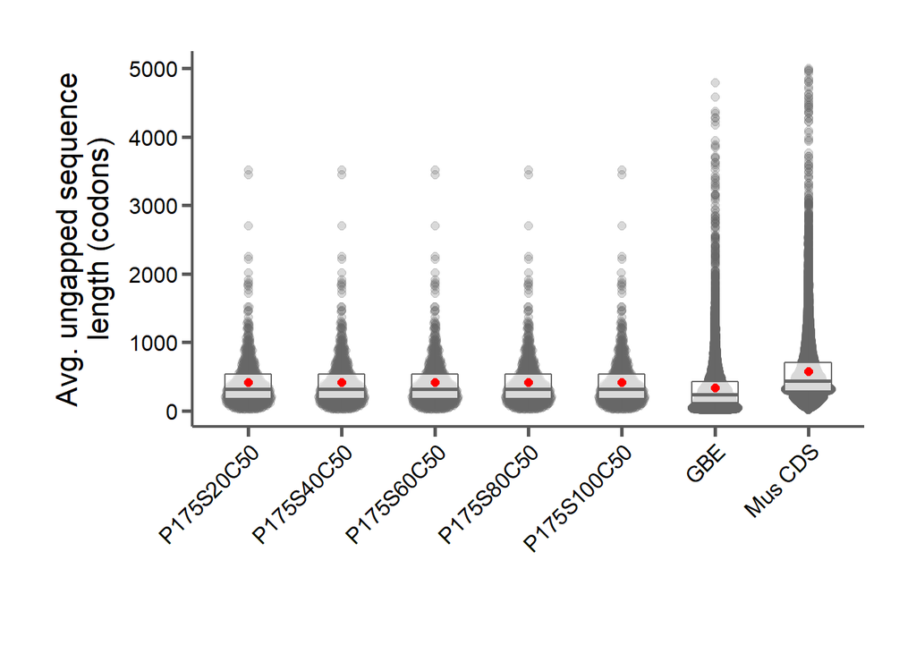

```r
#gbe_seqs = select(gbe_data, align, pre.codon.aln.length)
gbe_data$label = "GBE"
names(gbe_data)[4] = "post.avg.nongap.length"
gbe_lens = select(gbe_data, align, label, post.avg.nongap.length)
gbe_lens = subset(gbe_lens, post.avg.nongap.length < 10000)

mus_lens = select(mus_data, transcript_id, target_length)
mus_lens = mus_lens %>% group_by(transcript_id) %>% summarize(post.avg.nongap.length=sum(target_length))
mus_lens$post.avg.nongap.length = mus_lens$post.avg.nongap.length / 3
mus_lens$label = "Mus CDS"
names(mus_lens)[1] = "align"
mus_lens = subset(mus_lens, post.avg.nongap.length < 5000)


p_data = rbind(p175s20c50, p175s40c50, p175s60c50, p175s80c50, p175s100c50)
p_data = select(p_data, align, label, post.avg.nongap.length)

p_data = rbind(p_data, gbe_lens, mus_lens)

p_means = select(p_data, label, post.avg.nongap.length)
p_means = p_means %>% group_by(label) %>% summarize(post.avg.nongap.length=mean(post.avg.nongap.length, na.rm=T))

p_data$label = factor(p_data$label, levels=c("P175S20C50", "P175S40C50", "P175S60C50", "P175S80C50", "P175S100C50", "GBE", "Mus CDS"), ordered=T)
#levels(p_data$label) = c("P0S20C50", "P50S20C50", "P100S20C50", "P150S20C50", "P175S20C50", "P200S20C50", "GBE"), ordered=T)


p_means$label = factor(p_means$label, levels=c("P175S20C50", "P175S40C50", "P175S60C50", "P175S80C50", "P175S100C50", "GBE", "Mus CDS"), ordered=T)
#p_means$label = as.factor(p_means$label)
#levels(p_means$label) = c("P0S20C50", "P50S20C50", "P100S20C50", "P150S20C50", "P175S20C50", "P200S20C50")

p_lens = ggplot(p_data, aes(x=label, y=post.avg.nongap.length, group=label)) +
  geom_quasirandom(size=2, width=0.25, alpha=0.25, color="#666666") +
  geom_boxplot(outlier.shape=NA, alpha=0.75, width=0.5, color="#666666") +
  geom_point(data=p_means, aes(x=label, y=post.avg.nongap.length), size=2, color="red") +
  geom_line(data=p_means, aes(x=label, y=post.avg.nongap.length), size=2, color="blue") +
  ylab("Avg. ungapped sequence\nlength (codons)") +
  xlab("") +
  #scale_fill_manual(labels=c("Pre-filter", "Post-filter"), values=filter_col) +
  #scale_x_discrete(labels=c("Pre-filter", "Post-filter")) +
  #scale_y_continuous(expand=c(0,0)) +
  bartheme() +
  theme(legend.position="none", axis.text.x = element_text(angle=45, hjust=1))
print(p_lens)
```

```r
p_means %>% kable() %>% kable_styling(bootstrap_options=c("striped", "condended", "responsive"), full_width=F)
```

| label | post.avg.nongap.length |
| --- | --- |
| GBE | 332.1052 |
| Mus CDS | 569.7054 |
| P175S100C50 | 409.8810 |
| P175S20C50 | 409.8810 |
| P175S40C50 | 409.8810 |
| P175S60C50 | 409.8810 |
| P175S80C50 | 409.8810 |

## Varying the codon site (C) filter

Filtering three-codon windows where at least 2 codons have at least 2 gaps in greater than [25, 50, 75, 100]% of samples

Alignment length (codons)

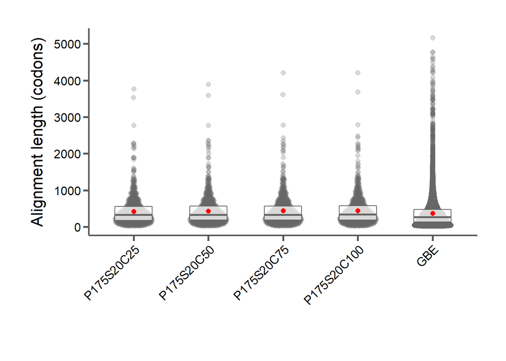

```r
#gbe_seqs = select(gbe_data, align, pre.codon.aln.length)
gbe_data$label = "GBE"
names(gbe_data)[3] = "post.codon.aln.length"
gbe_lens = select(gbe_data, align, label, post.codon.aln.length)
gbe_lens = subset(gbe_lens, post.codon.aln.length < 10000)


p_data = rbind(p175s20c25, p175s20c50, p175s20c75, p175s20c100)
p_data = select(p_data, align, label, post.codon.aln.length)

p_data = rbind(p_data, gbe_lens)

p_means = select(p_data, label, post.codon.aln.length)
p_means = p_means %>% group_by(label) %>% summarize(post.codon.aln.length=mean(post.codon.aln.length, na.rm=T))

p_data$label = factor(p_data$label, levels=c("P175S20C25", "P175S20C50", "P175S20C75", "P175S20C100", "GBE"), ordered=T)
#levels(p_data$label) = c("P0S20C50", "P50S20C50", "P100S20C50", "P150S20C50", "P0S20C50", "P200S20C50", "GBE"), ordered=T)


p_means$label = factor(p_means$label, levels=c("P175S20C25", "P175S20C50", "P175S20C75", "P175S20C100", "GBE"), ordered=T)
#p_means$label = as.factor(p_means$label)
#levels(p_means$label) = c("P0S20C50", "P50S20C50", "P100S20C50", "P150S20C50", "P0S20C50", "P200S20C50")

p_lens = ggplot(p_data, aes(x=label, y=post.codon.aln.length, group=label)) +
  geom_quasirandom(size=2, width=0.25, alpha=0.25, color="#666666") +
  geom_boxplot(outlier.shape=NA, alpha=0.75, width=0.5, color="#666666") +
  geom_point(data=p_means, aes(x=label, y=post.codon.aln.length), size=2, color="red") +
  geom_line(data=p_means, aes(x=label, y=post.codon.aln.length), size=2, color="blue") +
  ylab("Alignment length (codons)") +
  xlab("") +
  #scale_fill_manual(labels=c("Pre-filter", "Post-filter"), values=filter_col) +
  #scale_x_discrete(labels=c("Pre-filter", "Post-filter")) +
  #scale_y_continuous(expand=c(0,0)) +
  bartheme() +
  theme(legend.position="none", axis.text.x = element_text(angle=45, hjust=1))
print(p_lens)
```

```r
p_means %>% kable() %>% kable_styling(bootstrap_options=c("striped", "condended", "responsive"), full_width=F)
```

| label | post.codon.aln.length |
| --- | --- |
| GBE | 372.6928 |
| P175S20C100 | 443.5806 |
| P175S20C25 | 424.4600 |
| P175S20C50 | 433.4337 |
| P175S20C75 | 438.0705 |

Ungapped alignment length (codons)

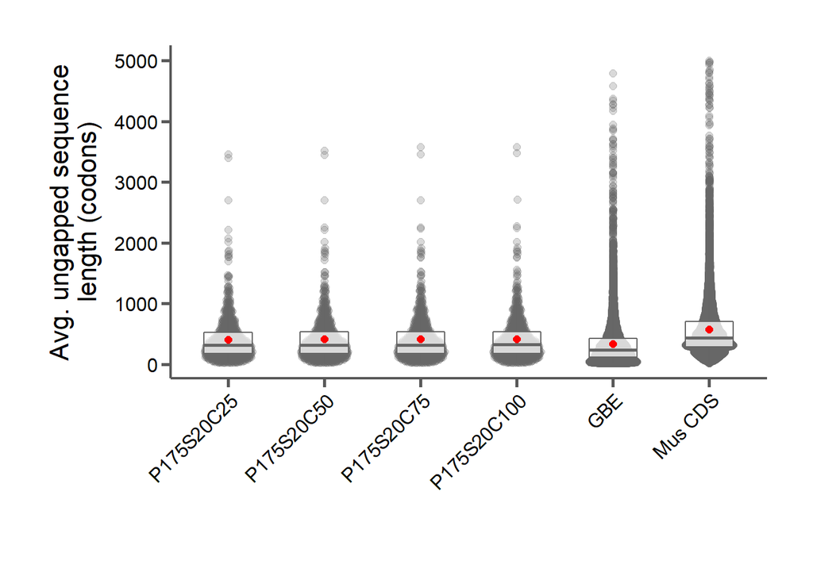

```r
#gbe_seqs = select(gbe_data, align, pre.codon.aln.length)
gbe_data$label = "GBE"
names(gbe_data)[4] = "post.avg.nongap.length"
gbe_lens = select(gbe_data, align, label, post.avg.nongap.length)
gbe_lens = subset(gbe_lens, post.avg.nongap.length < 10000)

mus_lens = select(mus_data, transcript_id, target_length)
mus_lens = mus_lens %>% group_by(transcript_id) %>% summarize(post.avg.nongap.length=sum(target_length))
mus_lens$post.avg.nongap.length = mus_lens$post.avg.nongap.length / 3
mus_lens$label = "Mus CDS"
names(mus_lens)[1] = "align"
mus_lens = subset(mus_lens, post.avg.nongap.length < 5000)


p_data = rbind(p175s20c25, p175s20c50, p175s20c75, p175s20c100)
p_data = select(p_data, align, label, post.avg.nongap.length)

p_data = rbind(p_data, gbe_lens, mus_lens)

p_means = select(p_data, label, post.avg.nongap.length)
p_means = p_means %>% group_by(label) %>% summarize(post.avg.nongap.length=mean(post.avg.nongap.length, na.rm=T))

p_data$label = factor(p_data$label, levels=c("P175S20C25", "P175S20C50", "P175S20C75", "P175S20C100", "GBE", "Mus CDS"), ordered=T)
#levels(p_data$label) = c("P0S20C50", "P50S20C50", "P100S20C50", "P150S20C50", "P175S20C50", "P200S20C50", "GBE"), ordered=T)


p_means$label = factor(p_means$label, levels=c("P175S20C25", "P175S20C50", "P175S20C75", "P175S20C100", "GBE", "Mus CDS"), ordered=T)
#p_means$label = as.factor(p_means$label)
#levels(p_means$label) = c("P0S20C50", "P50S20C50", "P100S20C50", "P150S20C50", "P175S20C50", "P200S20C50")

p_lens = ggplot(p_data, aes(x=label, y=post.avg.nongap.length, group=label)) +
  geom_quasirandom(size=2, width=0.25, alpha=0.25, color="#666666") +
  geom_boxplot(outlier.shape=NA, alpha=0.75, width=0.5, color="#666666") +
  geom_point(data=p_means, aes(x=label, y=post.avg.nongap.length), size=2, color="red") +
  geom_line(data=p_means, aes(x=label, y=post.avg.nongap.length), size=2, color="blue") +
  ylab("Avg. ungapped sequence\nlength (codons)") +
  xlab("") +
  #scale_fill_manual(labels=c("Pre-filter", "Post-filter"), values=filter_col) +
  #scale_x_discrete(labels=c("Pre-filter", "Post-filter")) +
  #scale_y_continuous(expand=c(0,0)) +
  bartheme() +
  theme(legend.position="none", axis.text.x = element_text(angle=45, hjust=1))
print(p_lens)
```

```r
p_means %>% kable() %>% kable_styling(bootstrap_options=c("striped", "condended", "responsive"), full_width=F)
```

| label | post.avg.nongap.length |
| --- | --- |
| GBE | 332.1052 |
| Mus CDS | 569.7054 |
| P175S20C100 | 412.5105 |
| P175S20C25 | 405.2061 |
| P175S20C50 | 409.8810 |
| P175S20C75 | 411.0848 |

```r
# Exonerate CDS diff between mouse and target seqs
mus_data = read.csv("../../data/Mus_best_cds_metadata.csv", header=TRUE)
#aln_data = read.csv("../../data/full-2-exonerate-to-cds-2.log", sep="\t", comment.char="#", header=F)
#in_data = read.csv("../../data/exonerate-indiv-target-test-seq-exonerate-to-cds-indiv.log", sep="\t", comment.char="#",
in_data = read.csv("../../data/exonerate-to-cds-p2g-concat.log", sep="\t", comment.char="#",header=TRUE)
#names(aln_data) = c("pid", "sample", "num.cds", "cds.len")
```

```r
target_data = filter(in_data, sample != "mm10" & sample != "rnor6")

orig_p = ggplot(target_data, aes(x=orig.seg.sim)) +
  geom_histogram() +
  scale_y_continuous(expand=c(0,0)) +
  bartheme()
print(orig_p)

final_p = ggplot(target_data, aes(x=final.seg.sim)) +
  geom_histogram() +
  scale_y_continuous(expand=c(0,0)) +
  bartheme()
print(final_p)

bins = seq(0,100,by=1)
bin_labels = seq(1,100,by=1)
orig_counts = hist(target_data$orig.seg.sim, breaks=bins, include.lowest=T, plot=F)$counts
orig_binned = data.frame("bin"=bin_labels, "count"=orig_counts, filter="With stop codons")


final_counts = hist(target_data$final.seg.sim, breaks=bins, include.lowest=T, plot=F)$counts
final_binned = data.frame("bin"=bin_labels, "count"=final_counts, filter="Without stop codons")

# orig_binned = binData(target_data, "orig.seg.sim", 100)
# orig_binned$filter = "With stop codons"
#
# final_binned = binData(target_data, "final.seg.sim", 100)
# final_binned$filter = "Without stop codons"

binned_data = rbind.fill(orig_binned, final_binned)
col = corecol(pal="wilke", numcol=2)
lab = c("With stop codons", "Without stop codons")
ylabels = as.character(seq(from=-50000, to=50000, by=10000))

dualp = ggplot(binned_data, aes(x = bin, y = ifelse(filter == "Without stop codons",-1, 1)*count, fill = filter)) +
  geom_col(width=1) +
  geom_hline(yintercept=0) +
  scale_x_continuous(name = "% AA similarity", limits = c(60, 105), expand = c(0, 0)) +
  scale_y_continuous(name = "# of segments", limits=c(-50000,50000), breaks = 10000*(-5:5), labels=ylabels) +
  scale_fill_manual(name="", limits=lab, values=col) +
  bartheme()
print(dualp)




orig_sim_data = select(target_data, pid, target, sample, orig.seg.sim)
names(orig_sim_data)[4] = "sim"
orig_sim_data$label = "With stop codons"

final_sim_data =select(target_data, pid, target, sample, final.seg.sim)
names(final_sim_data)[4] = "sim"
final_sim_data$label = "Without stop codons"

sim_data = rbind(orig_sim_data, final_sim_data)

scaff_batch_p = ggplot(sim_data, aes(x=label, y=sim, fill=label)) +
  geom_quasirandom(size=2, alpha=0.7, width=0.25, color="#d3d3d3") +
  geom_boxplot(outlier.shape=NA, alpha=0.7, width=0.5) +
  scale_fill_manual(labels=c("With stop codons", "Without stop codons"),
                     values=c("#920000", "#333333")) +

  labs(x="", y="% AA similarity") +
  #scale_x_discrete(labels=c("Original 40", "Rattus 8", "Mus 14", "New 70", "Aussie 57", "New 21")) +
  bartheme() +
  theme(legend.position="none",
        axis.text.x = element_text(angle=25, hjust=1))

print(scaff_batch_p)



no_stop_data = subset(target_data, seg.stops==0)
stop_data = subset(target_data, seg.stops > 0)

bins = seq(0,100,by=1)
bin_labels = seq(1,100,by=1)
orig_counts = hist(stop_data$orig.seg.sim, breaks=bins, include.lowest=T, plot=F)$counts
orig_binned = data.frame("bin"=bin_labels, "count"=orig_counts, filter="With stop codons")


final_counts = hist(no_stop_data$orig.seg.sim, breaks=bins, include.lowest=T, plot=F)$counts
final_binned = data.frame("bin"=bin_labels, "count"=final_counts, filter="Without stop codons")

# orig_binned = binData(target_data, "orig.seg.sim", 100)
# orig_binned$filter = "With stop codons"
#
# final_binned = binData(target_data, "final.seg.sim", 100)
# final_binned$filter = "Without stop codons"

binned_data = rbind.fill(orig_binned, final_binned)
col = corecol(pal="wilke", numcol=2)
lab = c("With stop codons", "Without stop codons")
ylabels = as.character(seq(from=-50000, to=50000, by=10000))

dualp = ggplot(binned_data, aes(x = bin, y = ifelse(filter == "Without stop codons",-1, 1)*count, fill = filter)) +
  geom_col(width=1) +
  geom_hline(yintercept=0) +
  scale_x_continuous(name = "% AA similarity", limits = c(60, 105), expand = c(0, 0)) +
  scale_y_continuous(name = "# of segments", limits=c(-50000,50000), breaks = 10000*(-5:5), labels=ylabels) +
  scale_fill_manual(name="", limits=lab, values=col) +
  bartheme()
print(dualp)






stop_sim_data = select(stop_data, pid, target, sample, orig.seg.sim, orig.seg.len)
names(stop_sim_data)[4] = "sim"
names(stop_sim_data)[5] = "len"
stop_sim_data$label = "With stop codons"

stop_sim_data_final = select(stop_data, pid, target, sample, final.seg.sim, final.seg.len)
names(stop_sim_data_final)[4] = "sim"
names(stop_sim_data_final)[5] = "len"
stop_sim_data_final$label = "With stop codons (final)"

no_stop_sim_data =select(no_stop_data, pid, target, sample, orig.seg.sim, orig.seg.len)
names(no_stop_sim_data)[4] = "sim"
names(no_stop_sim_data)[5] = "len"
no_stop_sim_data$label = "Without stop codons"

sim_data = rbind(stop_sim_data, stop_sim_data_final, no_stop_sim_data)

sim_p = ggplot(sim_data, aes(x=label, y=sim, fill=label)) +
  geom_quasirandom(size=2, alpha=0.7, width=0.25, color="#d3d3d3") +
  geom_boxplot(outlier.shape=NA, alpha=0.7, width=0.5) +
  scale_fill_manual(labels=c("With stop codons", "With stop codons (final)", "Without stop codons"),
                     values=corecol(numcol=3, offset=2)) +

  labs(x="", y="% AA similarity") +
  #scale_x_discrete(labels=c("Original 40", "Rattus 8", "Mus 14", "New 70", "Aussie 57", "New 21")) +
  bartheme() +
  theme(legend.position="none",
        axis.text.x = element_text(angle=25, hjust=1))

print(sim_p)



len_p = ggplot(sim_data, aes(x=label, y=len, fill=label)) +
  geom_quasirandom(size=2, alpha=0.7, width=0.25, color="#d3d3d3") +
  geom_boxplot(outlier.shape=NA, alpha=0.7, width=0.5) +
  scale_fill_manual(labels=c("With stop codons", "With stop codons (final)", "Without stop codons"),
                     values=corecol(numcol=3, offset=2)) +

  labs(x="", y="% AA similarity") +
  #scale_x_discrete(labels=c("Original 40", "Rattus 8", "Mus 14", "New 70", "Aussie 57", "New 21")) +
  bartheme() +
  theme(legend.position="none",
        axis.text.x = element_text(angle=25, hjust=1))

print(len_p)
```

[output not shown]

```r
#aln_data$num.diff = NA
#num_data = data.frame("sample"=c(), "num.diff"=c())

sample_data = select(in_data, pid, sample, num.cds.protein, final.segs, cds.protein.len, final.full.len)
sample_data = unique(sample_data)

mm10_data = subset(sample_data, sample=="mm10")
sample_data = merge(sample_data, mm10_data, by="pid")
sample_data = subset(sample_data, sample.x!="mm10")
sample_data$is.rat = "NO"
sample_data$is.rat[sample_data$sample.x=="rnor6"] = "YES"

sample_data$cds.diff = sample_data$final.segs.x - sample_data$num.cds.protein.y
sample_data$len.diff = sample_data$final.full.len.x - sample_data$cds.protein.len.y
```

```r
# Exonerate predictions vs. mouse
cds_p = ggplot(sample_data, aes(x=cds.diff)) +
  #geom_quasirandom(aes(color=is.rat), size=2, alpha=0.7, width=0.25) +
  geom_histogram(bins=50, color="#333333", fill=corecol(numcol=1)) +
  xlab("# predicted CDS - # mouse CDS") +
  ylab("# sequences") +
  scale_y_continuous(expand=c(0,0)) +
  bartheme()
print(cds_p)
```

[output not shown]

```r
len_p = ggplot(sample_data, aes(x=len.diff)) +
  #geom_quasirandom(aes(color=is.rat), size=2, alpha=0.7, width=0.25) +
  geom_histogram(bins=50, color="#333333", fill=corecol(numcol=1, offset=1)) +
  xlab("predicted CDS length - mouse CDS length") +
  ylab("# sequences") +
  scale_y_continuous(expand=c(0,0)) +
  bartheme()
print(len_p)
```

[output not shown]

```r
# MACSE pre-trimming
trim_data = read.csv("../../data/06-cds-trim-stats.csv", header=TRUE, sep=";", stringsAsFactors=F)
trim_data$perc.kept = as.numeric(trim_data$nbKeep) / as.numeric(trim_data$initialSeqLength)

len_p = ggplot(subset(trim_data, perc.kept >= 0.9), aes(x=perc.kept)) +
  #geom_quasirandom(aes(color=is.rat), size=2, alpha=0.7, width=0.25) +
  geom_histogram(color="#333333", fill=corecol(numcol=1, offset=1)) +
  xlab("% sequence kept") +
  ylab("# sequences") +
  scale_y_continuous(expand=c(0,0)) +
  bartheme()
print(len_p)
```

[output not shown]

```r
cat("Page last updated:", format(Sys.time(), "%m/%d/%Y %H:%M:%S %Z"))
```

```
## Page last updated: 03/23/2021 12:11:46 MDT
```

```r
htmltools::includeHTML("../html-chunks/rmd_footer.html")
```